# Специфика медицинских данных

```r
library(readxl)
library(dplyr)
library(ggplot2)
trauma_data <- read_xlsx('/home/daria/PycharmProjects/BioStat_2023/20231117_meddata/trauma.xlsx')
```

```r
reference_range_male <- c(13.5, 16)
reference_range_female <- c(12, 14)

# Assuming 'Sex' is the variable indicating gender
cases_below_reference <- trauma_data %>%
  filter(
    (Sex == "Male" & Hb < reference_range_male[1]) |
    (Sex == "Female" & Hb < reference_range_female[1])
  )

num_cases_below_reference <- nrow(cases_below_reference)
percentage_cases_below_reference <- (num_cases_below_reference / nrow(trauma_data)) * 100

cat("Количество пациентов с пониженным гемоглобином:", num_cases_below_reference, "\n")
```

```
Количество пациентов с пониженным гемоглобином: 474
```

```r
cat("Процент пациентов с пониженным гемоглобином:", percentage_cases_below_reference, "%\n")
```

```
Процент пациентов с пониженным гемоглобином: 46.28906 %
```

2. Рассчитайте индекс массы тела у пациентов (кг / м2). Каков был средний (M (SD)) уровень ИМТ у пациентов, включённых в исследование? Какая доля пациентов имела ожирение (ИМТ > 30)?

```r
trauma_data$Height <- as.numeric(stringr::str_remove_all(trauma_data$Height, '\"'))
trauma_data$Height_meters <- as.numeric(stringr::str_remove_all(trauma_data$Height, '\"')) * 0.0254
trauma_data$Weight_kg <- as.numeric(trauma_data$Weight) * 0.453592

# Calculate BMI
trauma_data$BMI <- trauma_data$Weight_kg / (trauma_data$Height_meters^2)

# Display descriptive statistics for BMI
summary(trauma_data$BMI)
```

```
   Min. 1st Qu.  Median    Mean 3rd Qu.    Max.
  18.44   24.25   25.91   26.00   27.71   34.74
```

```r
# Calculate the mean and standard deviation of BMI
mean_bmi <- mean(trauma_data$BMI, na.rm = TRUE)
sd_bmi <- sd(trauma_data$BMI, na.rm = TRUE)

# Calculate the percentage of patients with obesity (BMI > 30)
percentage_obese <- mean(trauma_data$BMI > 30, na.rm = TRUE) * 100

# Display the results
cat("Средний BMI:", mean_bmi, "\n")
```

```
Средний BMI: 26.00361
```

```r
cat("Стандартное отклонение BMI:", sd_bmi, "\n")
```

```
Стандартное отклонение BMI: 2.566121
```

```r
cat("Процент пациентов с ожирением (BMI > 30):", percentage_obese, "%\n")
```

```
Процент пациентов с ожирением (BMI > 30): 6.738281 %
```

3. Как выглядит ROC-кривая для предсказания летального исхода в течение 24 часов по переменной, характеризующей уровень гемоглобина? Постройте график. Чем может быть обусловлена такая форма кривой?

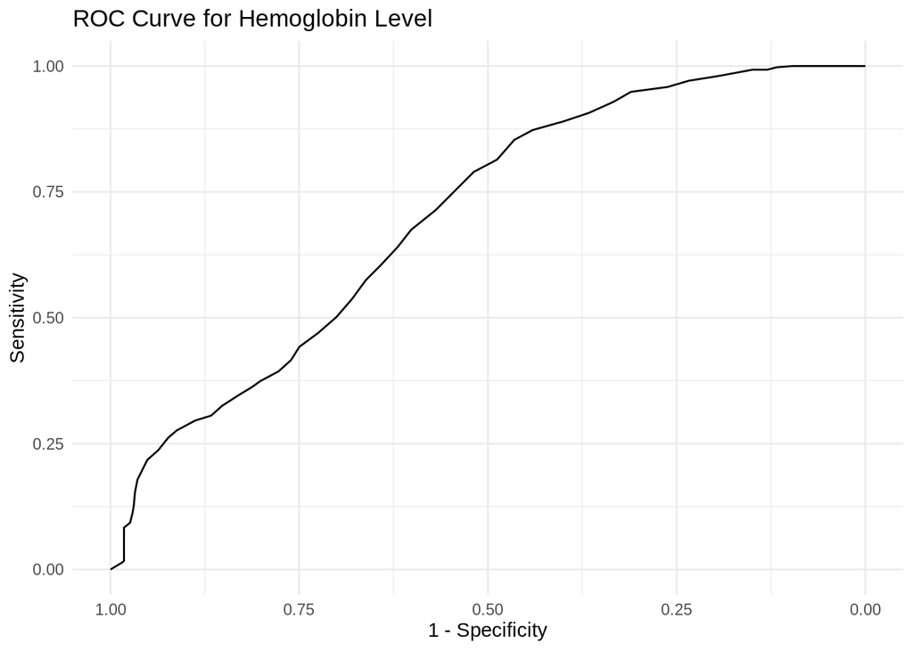

```r
library(pROC)
roc_curve <- roc(trauma_data$Death, trauma_data$Hb)
# Plot the ROC curve
ggroc(roc_curve) +
  labs(title = "ROC Curve for Hemoglobin Level",
       x = "1 - Specificity",
       y = "Sensitivity") +
  theme_minimal()
```

```r
roc_coordinates <- coords(roc_curve)

# Display the first few rows of the coordinates
head(roc_coordinates)
```

|  | threshold | specificity | sensitivity |
| --- | --- | --- | --- |
| 1 | Inf | 0.000000000 | 1 |
| 2 | 16.05 | 0.001626016 | 1 |
| 3 | 15.85 | 0.004878049 | 1 |
| 4 | 15.75 | 0.009756098 | 1 |
| 5 | 15.65 | 0.013008130 | 1 |
| 6 | 15.50 | 0.016260163 | 1 |

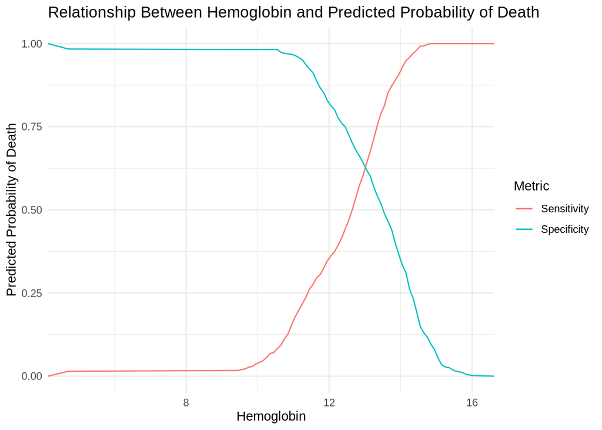

```r
ggplot() +
  # Plot the first line (sensitivity)
  geom_line(data = data.frame(Hb = roc_coordinates$threshold, Prob_Death = roc_coordinates$sensitivity),
            aes(x = Hb, y = Prob_Death, color = "Sensitivity")) +

  # Plot the second line (specificity)
  geom_line(data = data.frame(Hb = roc_coordinates$threshold, Prob_Death =  roc_coordinates$specificity),
            aes(x = Hb, y = Prob_Death, color = "Specificity")) +

  labs(title = "Relationship Between Hemoglobin and Predicted Probability of Death",
       x = "Hemoglobin",
       y = "Predicted Probability of Death",
       color = "Metric") +
  theme_minimal()
```

Чему равна площадь под ROC-кривой, которую вы построили в вопросе 3? Чему равен 95% двусторонний ДИ для площади под ROC-кривой, которую вы построили в вопросе 3?

```r
auc_value <- auc(roc_curve)
ci_auc <- ci.auc(roc_curve)
cat("AUC:", auc_value, "\n")
```

```
AUC: 0.7005983
```

```r
cat("95% ДИ:", ci_auc[1], "-", ci_auc[3], "\n")
```

```
95% ДИ: 0.6691296 - 0.732067
```

5. Проведите ROC-анализ и определите, какое пороговое значение является оптимальным для предсказания летального исхода в течение 24 часов по шкале комы Глазго. Какой чувствительностью и специфичностью обладает данный порог?

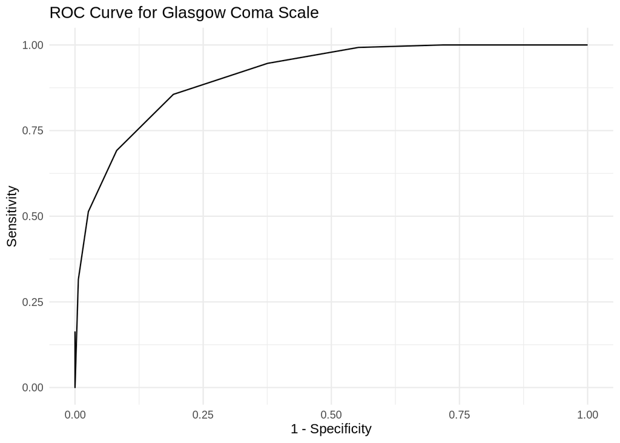

```r
roc_curve_gcs <- roc(trauma_data$Death, trauma_data$GSC)
ggplot(as.data.frame(coords(roc_curve_gcs, "all")),
                       aes(x = 1 - specificity, y = sensitivity)) +
  geom_line() +
  labs(title = "ROC Curve for Glasgow Coma Scale",
       x = "1 - Specificity",
       y = "Sensitivity") +
  theme_minimal()
```

```r
roc_curve_gcs  %>% coords(x = "best", best.method = "closest.topleft")
```

| threshold | specificity | sensitivity |
| --- | --- | --- |
| 7.5 | 0.8081301 | 0.8557457 |

6. Какая из количественных переменных в датасете (включая рассчитанный вами ранее ИМТ) обладает наибольшей площадью под ROC-кривой? Как вы можете интерпретировать это знание? Какая количественная переменная имеет наименьшую площадь?

```r
library(tidyr)
trauma_data$height_reversed <- 1-trauma_data$Height
trauma_data %>%
    select("id",
           "Age",
           "Height",
           "height_reversed",
           "Weight",
           "SBP",
           "DBP",
           "FOUR",
           "GSC",
           "Hb",
           "BMI",
           "Death") %>%
    pivot_longer(cols = !Death) %>%
    group_by(name) %>%
    summarise(AUC = roc(Death, value, ci = T)$ci[2] %>% round(3),
              AUC_LCL = roc(Death, value, ci = T)$ci[1] %>% round(3),
              AUC_UCL = roc(Death, value, ci = T)$ci[3] %>% round(3))
```

| name | AUC | AUC_LCL | AUC_UCL |
| --- | --- | --- | --- |
| Age | 0.527 | 0.491 | 0.563 |
| BMI | 0.502 | 0.465 | 0.538 |
| DBP | 0.744 | 0.714 | 0.774 |
| FOUR | 0.934 | 0.920 | 0.948 |
| GSC | 0.912 | 0.896 | 0.929 |
| Hb | 0.701 | 0.669 | 0.732 |
| Height | 0.482 | 0.445 | 0.518 |
| SBP | 0.786 | 0.759 | 0.814 |
| Weight | 0.518 | 0.482 | 0.554 |
| height_reversed | 0.518 | 0.482 | 0.555 |

[output cut: 1 more lines]

Наибольшее AUC получается при использовании колонки FOUR, которая в свою очередь шкала комы при поступлении, учитывающая глазные, двигательные, стволовые, дыхательные реакции и паттерны. Чем выше значение AUC тем лучше можно предсказать response переменную (выше чувствительность и точность). Получается что FOUR имеет наибольшую предсказательную силу.

Наименьшее AUC получается при использовании колонки Height. Однако, если использовать значения 1-Height (обратная зависимость смертности от роста), то она перестанет быть самой меньшей. И тогда видно что ближе всего к площади равной 0.5 колонка BMI, она и является наименьшей по площади.

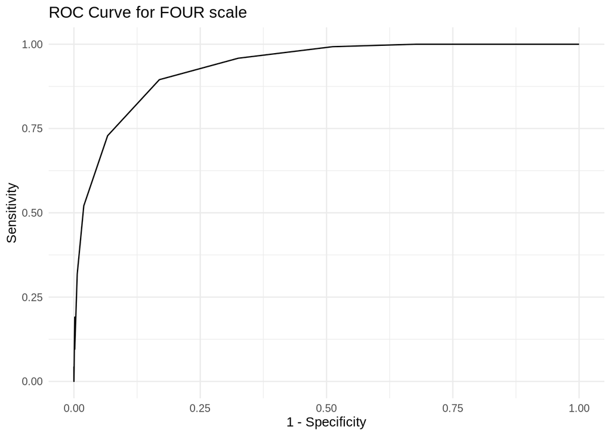

```r
roc_curve_gcs <- roc(trauma_data$Death, trauma_data$FOUR)
ggplot(as.data.frame(coords(roc_curve_gcs, "all")),
                       aes(x = 1 - specificity, y = sensitivity)) +
  geom_line() +
  labs(title = "ROC Curve for FOUR scale",
       x = "1 - Specificity",
       y = "Sensitivity") +
  theme_minimal()
```